# Non-Parametric Analysis

## Business Understanding

Good quality wine is typically characterized by a balance of several factors including acidity, tannins, alcohol content, sweetness, and the wine’s overall structure. Wine quality is often judged by consumers based on taste preferences, which may vary by region, culture, and even personal preference. Generally, higher-quality wines tend to have well-balanced acidity and alcohol levels, appropriate residual sugar content, and fewer defects, such as high volatile acidity. Wine ratings, like those used in this dataset, are often influenced by expert panels and consumer reviews, which typically rate the wines on a scale (e.g., 1-10). Factors such as the vineyard’s terroir (environmental factors), the grape variety, and production techniques such as fermentation temperature and time, also play significant roles in determining the final quality.

## Data Understanding

The dataset used for this analysis comes from the UCI Wine Quality Database and includes chemical and sensory attributes of red and white wines, specifically:

Fixed Acidity: Influences the taste of the wine, contributing to its tartness and aging potential. Volatile Acidity: A measure of wine spoilage, typically an undesirable trait at high levels. Citric Acid: Contributes to the wine’s freshness and acidity. Residual Sugar: Impacts the sweetness of the wine. Chlorides: Higher levels can result in undesirable salty flavors. Free Sulfur Dioxide: Helps preserve wine but excessive levels can result in an unpleasant taste. Total Sulfur Dioxide: A form of sulfur used in wine preservation. Density: Affects the mouthfeel and body of the wine. pH: Influences the wine’s acidity. Sulphates: Adds to the wine’s preservation and stability. Alcohol: A key factor influencing the body and taste of wine. Quality: A subjective rating assigned by consumers and wine experts.

## What Types are the Data?

Ratio: Fixed Acidity, Volatile Acidity, Citric Acid, Residual Sugar, Chlorides, Free Sulfur Dioxide, Total Sulfur Dioxide, Density, Sulphates, Alcohol

Interval: pH

Ordinal: Quality

This dataset has no missing values and consists of 6,497 instances from both red and white wines, providing a sufficient sample for analysis.

## Purpose

> We needed to extract some “actionable” insights from the UCI Wine Quality Data Set . The purpose is that a wine producer has hired us to better understand what factors affect wine quality. The producer can also look at which production factors have an effect on rating scores by consumers. The reason why we utilized exploratory data analysis is show different distributions of certain production techniques and why consumers probably favor one type of wine over the other.

## Loading and Installing the Required Packages and Data Loading and Merging

```r
required_packages <- c("tidyverse", "broom", "corrplot")
to_install <- setdiff(required_packages, installed.packages()[, "Package"])
if (length(to_install) > 0) install.packages(to_install)

# Core libraries for data wrangling, plotting, and correlation analysis
library(tidyverse)
library(dplyr)       # ensure dplyr functions like bind_rows are available
library(broom)
library(corrplot)
```

```r
# URLs for the datasets and other sources
red_url   <- "https://archive.ics.uci.edu/ml/machine-learning-databases/wine-quality/winequality-red.csv"
white_url <- "https://archive.ics.uci.edu/ml/machine-learning-databases/wine-quality/winequality-white.csv"
volatile_acidity_url <- "https://www.awri.com.au/wp-content/uploads/2018/03/s1982.pdf"

# Read data
red   <- read.csv(red_url, sep = ";")
white <- read.csv(white_url, sep = ";")

# Add type column
red$type   <- "red"
white$type <- "white"

# Combine using dplyr::bind_rows to ensure the function is found
data <- dplyr::bind_rows(red, white)
```

## Assumptions Check for Statistical Tests

```r
# Normality Check using Shapiro-Wilk Test
shapiro_red <- shapiro.test(filter(data, type == "red")$quality)
shapiro_white <- shapiro.test(filter(data, type == "white")$quality)

cat("Shapiro-Wilk Test for Red Wine:\n")
```

```
## Shapiro-Wilk Test for Red Wine:
```

```r
print(shapiro_red)
```

```
##
##  Shapiro-Wilk normality test
##
## data:  filter(data, type == "red")$quality
## W = 0.85759, p-value < 2.2e-16
```

```r
cat("\nShapiro-Wilk Test for White Wine:\n")
```

```
##
## Shapiro-Wilk Test for White Wine:
```

```r
print(shapiro_white)
```

```
##
##  Shapiro-Wilk normality test
##
## data:  filter(data, type == "white")$quality
## W = 0.88904, p-value < 2.2e-16
```

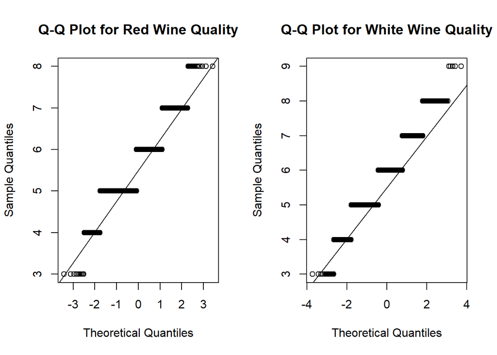

```r
# Q-Q Plots for Normality
par(mfrow = c(1, 2))  # Set up the plotting window to show two plots side by side
qqnorm(filter(data, type == "red")$quality, main = "Q-Q Plot for Red Wine Quality")
qqline(filter(data, type == "red")$quality)

qqnorm(filter(data, type == "white")$quality, main = "Q-Q Plot for White Wine Quality")
qqline(filter(data, type == "white")$quality)
```

```r
par(mfrow = c(1, 1))  # Reset the plotting window to default

# Homogeneity of Variances using Levene’s Test
library(car) # For leveneTest
levene_test <- leveneTest(quality ~ type, data = data)

cat("\nLevene's Test for Equality of Variances:\n")
```

```
##
## Levene's Test for Equality of Variances:
```

```r
print(levene_test)
```

```
## Levene's Test for Homogeneity of Variance (center = median)
##         Df F value Pr(>F)
## group    1  2.3327 0.1267
##       6495
```

```r
# Correlation Testing
cor_red_alc <- cor.test(filter(data, type == "red")$alcohol, filter(data, type == "red")$quality)
cor_white_alc <- cor.test(filter(data, type == "white")$alcohol, filter(data, type == "white")$quality)

cat("\nCorrelation Test Results for Alcohol vs Quality:\n")
```

```
##
## Correlation Test Results for Alcohol vs Quality:
```

```r
list(
  red = tidy(cor_red_alc),
  white = tidy(cor_white_alc)
)
```

```
## $red
## # A tibble: 1 × 8
##   estimate statistic  p.value parameter conf.low conf.high method    alternative
##      <dbl>     <dbl>    <dbl>     <int>    <dbl>     <dbl> <chr>     <chr>
## 1    0.476      21.6 2.83e-91      1597    0.437     0.513 Pearson'… two.sided
##
## $white
## # A tibble: 1 × 8
##   estimate statistic   p.value parameter conf.low conf.high method   alternative
##      <dbl>     <dbl>     <dbl>     <int>    <dbl>     <dbl> <chr>    <chr>
## 1    0.436      33.9 5.61e-226      4896    0.413     0.458 Pearson… two.sided
```

[figure not shown]

```r
# Scatter Plots for Alcohol vs Quality
par(mfrow = c(1, 2))  # Set up the plotting window to show two plots side by side
plot(filter(data, type == "red")$alcohol, filter(data, type == "red")$quality,
     main = "Red Wine: Alcohol vs Quality",
     xlab = "Alcohol", ylab = "Quality", pch = 19, col = "red")

plot(filter(data, type == "white")$alcohol, filter(data, type == "white")$quality,
     main = "White Wine: Alcohol vs Quality",
     xlab = "Alcohol", ylab = "Quality", pch = 19, col = "white")
```

```r
par(mfrow = c(1, 1))  # Reset the plotting window to default
```

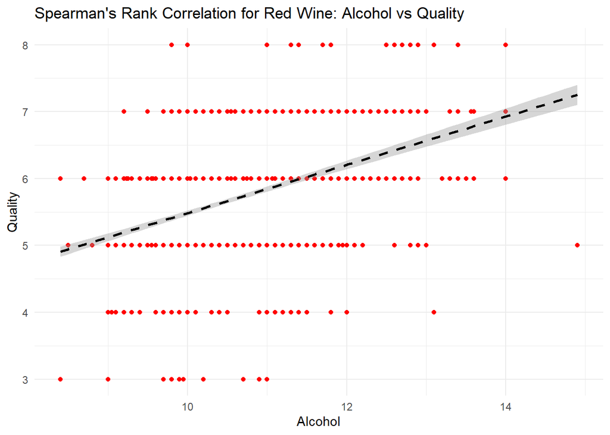

Spearman’s Rank Correlation and Mann-Whitney U Test Results

```r
# Non-parametric correlation using Spearman's rank correlation
cor_red_alc_spearman <- cor.test(filter(data, type == "red")$alcohol,
                                  filter(data, type == "red")$quality,
                                  method = "spearman")

cor_white_alc_spearman <- cor.test(filter(data, type == "white")$alcohol,
                                   filter(data, type == "white")$quality,
                                   method = "spearman")

# Spearman's Rank Correlation Scatter Plot with Line of Best Fit
library(ggplot2)
ggplot(filter(data, type == "red"), aes(x = alcohol, y = quality)) +
  geom_point(color = "red") +
  geom_smooth(method = "lm", color = "black", linetype = "dashed") +
  labs(title = "Spearman's Rank Correlation for Red Wine: Alcohol vs Quality",
       x = "Alcohol", y = "Quality") +
  theme_minimal()
```

[figure not shown]

Spearman’s Rank Correlation and Mann-Whitney U Test Results

```r
ggplot(filter(data, type == "white"), aes(x = alcohol, y = quality)) +
  geom_point(color = "white") +
  geom_smooth(method = "lm", color = "black", linetype = "dashed") +
  labs(title = "Spearman's Rank Correlation for White Wine: Alcohol vs Quality",
       x = "Alcohol", y = "Quality") +
  theme_minimal()
```

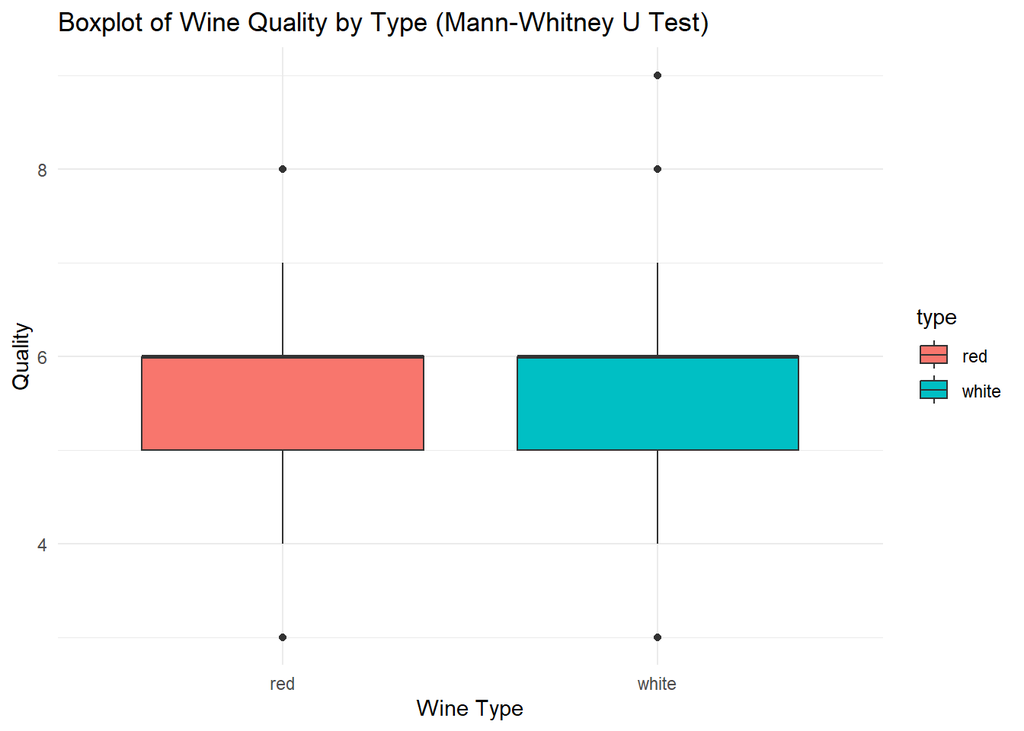

Spearman’s Rank Correlation and Mann-Whitney U Test Results

```r
# Mann-Whitney U Test Boxplot
ggplot(data, aes(x = type, y = quality, fill = type)) +
  geom_boxplot() +
  labs(title = "Boxplot of Wine Quality by Type (Mann-Whitney U Test)",
       x = "Wine Type", y = "Quality") +
  theme_minimal()
```

```r
# Display correlation test results
list(
  red   = tidy(cor_red_alc_spearman),
  white = tidy(cor_white_alc_spearman)
)
```

```
## $red
## # A tibble: 1 × 5
##   estimate  statistic  p.value method                          alternative
##      <dbl>      <dbl>    <dbl> <chr>                           <chr>
## 1    0.479 355321833. 2.73e-92 Spearman's rank correlation rho two.sided
##
## $white
## # A tibble: 1 × 5
##   estimate    statistic   p.value method                          alternative
##      <dbl>        <dbl>     <dbl> <chr>                           <chr>
## 1    0.440 10959902649. 1.66e-231 Spearman's rank correlation rho two.sided
```

```r
# Display Mann-Whitney U test results
mann_whitney_test <- wilcox.test(quality ~ type, data = data)
tidy(mann_whitney_test)
```

| statistic | p.value | method | alternative |
| --- | --- | --- | --- |
| 3311514 | 3.634341e-23 | Wilcoxon rank sum test with continuity correction | two.sided |

```r
# Sample sizes
glue::glue("Red: {nrow(red)}, White: {nrow(white)}, Total: {nrow(data)}")
```

```
## Red: 1599, White: 4898, Total: 6497
```

```r
# Structure and summary
glimpse(data)
```

```
## Rows: 6,497
## Columns: 13
## $ fixed.acidity        <dbl> 7.4, 7.8, 7.8, 11.2, 7.4, 7.4, 7.9, 7.3, 7.8, 7.5…
## $ volatile.acidity     <dbl> 0.700, 0.880, 0.760, 0.280, 0.700, 0.660, 0.600, …
## $ citric.acid          <dbl> 0.00, 0.00, 0.04, 0.56, 0.00, 0.00, 0.06, 0.00, 0…
## $ residual.sugar       <dbl> 1.9, 2.6, 2.3, 1.9, 1.9, 1.8, 1.6, 1.2, 2.0, 6.1,…
## $ chlorides            <dbl> 0.076, 0.098, 0.092, 0.075, 0.076, 0.075, 0.069, …
## $ free.sulfur.dioxide  <dbl> 11, 25, 15, 17, 11, 13, 15, 15, 9, 17, 15, 17, 16…
## $ total.sulfur.dioxide <dbl> 34, 67, 54, 60, 34, 40, 59, 21, 18, 102, 65, 102,…
## $ density              <dbl> 0.9978, 0.9968, 0.9970, 0.9980, 0.9978, 0.9978, 0…
## $ pH                   <dbl> 3.51, 3.20, 3.26, 3.16, 3.51, 3.51, 3.30, 3.39, 3…
## $ sulphates            <dbl> 0.56, 0.68, 0.65, 0.58, 0.56, 0.56, 0.46, 0.47, 0…
## $ alcohol              <dbl> 9.4, 9.8, 9.8, 9.8, 9.4, 9.4, 9.4, 10.0, 9.5, 10.…
## $ quality              <int> 5, 5, 5, 6, 5, 5, 5, 7, 7, 5, 5, 5, 5, 5, 5, 5, 7…
## $ type                 <chr> "red", "red", "red", "red", "red", "red", "red", …
```

```r
summary(data)
```

```
##  fixed.acidity    volatile.acidity  citric.acid     residual.sugar
##  Min.   : 3.800   Min.   :0.0800   Min.   :0.0000   Min.   : 0.600
##  1st Qu.: 6.400   1st Qu.:0.2300   1st Qu.:0.2500   1st Qu.: 1.800
##  Median : 7.000   Median :0.2900   Median :0.3100   Median : 3.000
##  Mean   : 7.215   Mean   :0.3397   Mean   :0.3186   Mean   : 5.443
##  3rd Qu.: 7.700   3rd Qu.:0.4000   3rd Qu.:0.3900   3rd Qu.: 8.100
##  Max.   :15.900   Max.   :1.5800   Max.   :1.6600   Max.   :65.800
##    chlorides       free.sulfur.dioxide total.sulfur.dioxide    density
##  Min.   :0.00900   Min.   :  1.00      Min.   :  6.0        Min.   :0.9871
##  1st Qu.:0.03800   1st Qu.: 17.00      1st Qu.: 77.0        1st Qu.:0.9923
##  Median :0.04700   Median : 29.00      Median :118.0        Median :0.9949
##  Mean   :0.05603   Mean   : 30.53      Mean   :115.7        Mean   :0.9947
##  3rd Qu.:0.06500   3rd Qu.: 41.00      3rd Qu.:156.0        3rd Qu.:0.9970
##  Max.   :0.61100   Max.   :289.00      Max.   :440.0        Max.   :1.0390
##        pH          sulphates         alcohol         quality
##  Min.   :2.720   Min.   :0.2200   Min.   : 8.00   Min.   :3.000
##  1st Qu.:3.110   1st Qu.:0.4300   1st Qu.: 9.50   1st Qu.:5.000
##  Median :3.210   Median :0.5100   Median :10.30   Median :6.000
##  Mean   :3.219   Mean   :0.5313   Mean   :10.49   Mean   :5.818
##  3rd Qu.:3.320   3rd Qu.:0.6000   3rd Qu.:11.30   3rd Qu.:6.000
##  Max.   :4.010   Max.   :2.0000   Max.   :14.90   Max.   :9.000
##      type
##  Length:6497
##  Class :character
##  Mode  :character
##
##
##
```

**Interpretation of `non-parametric-analysis`:** This visualization or summary highlights a key trend or distribution in the data. For example, examine how the variable in question relates to wine quality or type. Look for outliers, skewness, or differences that inform the business question. > The main reason why we ran this code was to see summary statistics for red and white wine. While doing this, we see that there are more white wine samples than red wine.

## Missing Values

```r
colSums(is.na(data))
```

```
##        fixed.acidity     volatile.acidity          citric.acid
##                    0                    0                    0
##       residual.sugar            chlorides  free.sulfur.dioxide
##                    0                    0                    0
## total.sulfur.dioxide              density                   pH
##                    0                    0                    0
##            sulphates              alcohol              quality
##                    0                    0                    0
##                 type
##                    0
```

> I ran this code to confirm that there is no missing data.

## Exploratory Data Analysis

### Quality Distribution

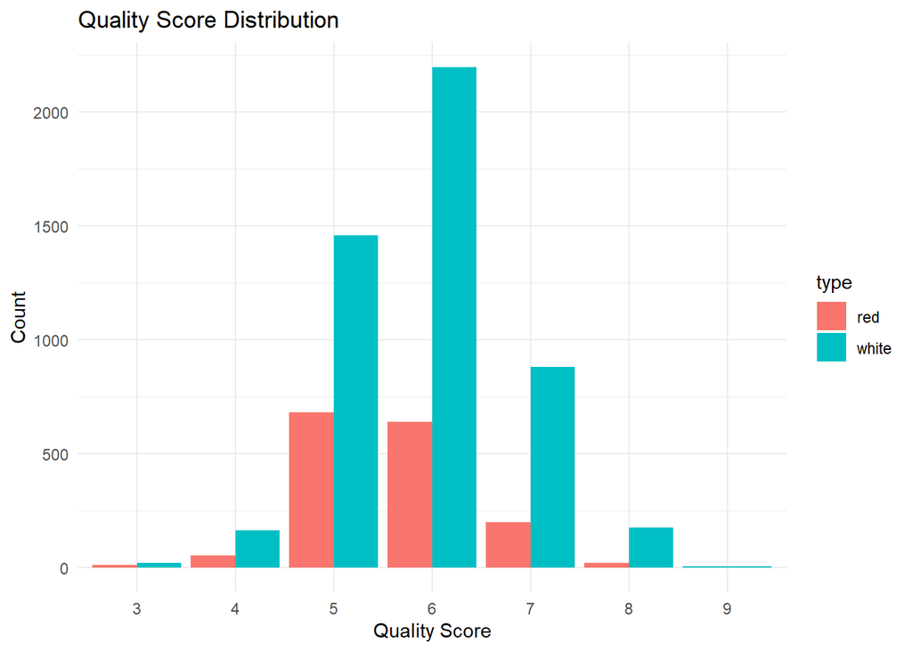

Distribution of Quality Scores by Wine Type

```r
ggplot(data, aes(x = factor(quality), fill = type)) +
  geom_bar(position = "dodge") +
  labs(title = "Quality Score Distribution",
       x = "Quality Score", y = "Count") +
  theme_minimal()
```

**Interpretation of `quality-distribution`:** This visualization or summary highlights a key trend or distribution in the data. For example, examine how the variable in question relates to wine quality or type. Look for outliers, skewness, or differences that inform the business question. > Red wine ratings have had stayed mainly in the five to six ranges. White wine ratings had higher ratings with six, seven, and eight. Reveals whether one wine type generally receives higher ratings. Additonally, white wine has an overall higher rating than red wine and shows an overall wider spread than it. In conclusion this can mean that white wine is more enjoyed than red wine to consumers. Another reason could be that white wine also outnumbers red wine in the amount of observations.

### Chemical Properties

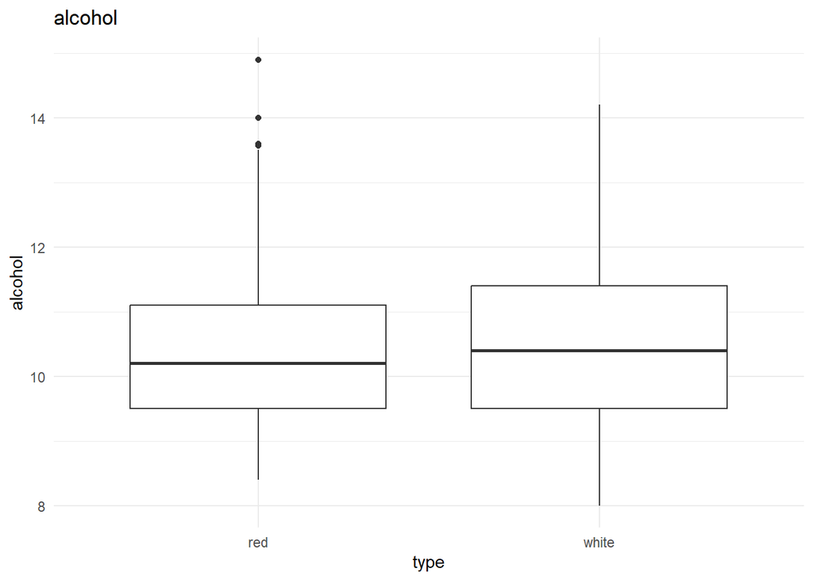

Key Chemical Properties by Wine Type

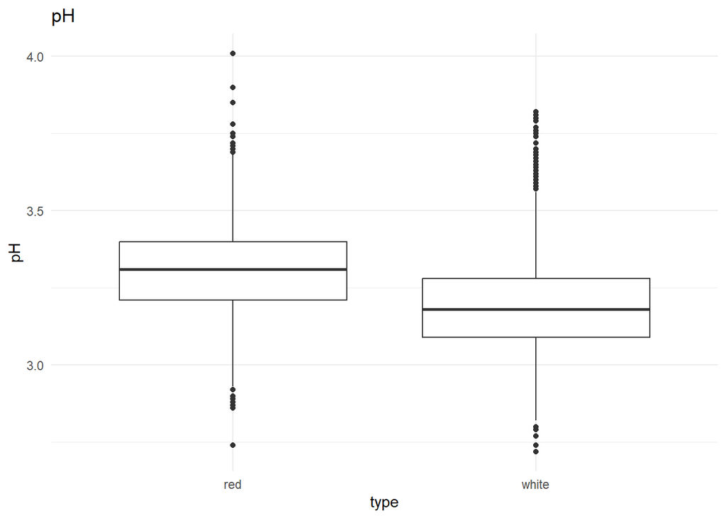

Key Chemical Properties by Wine Type

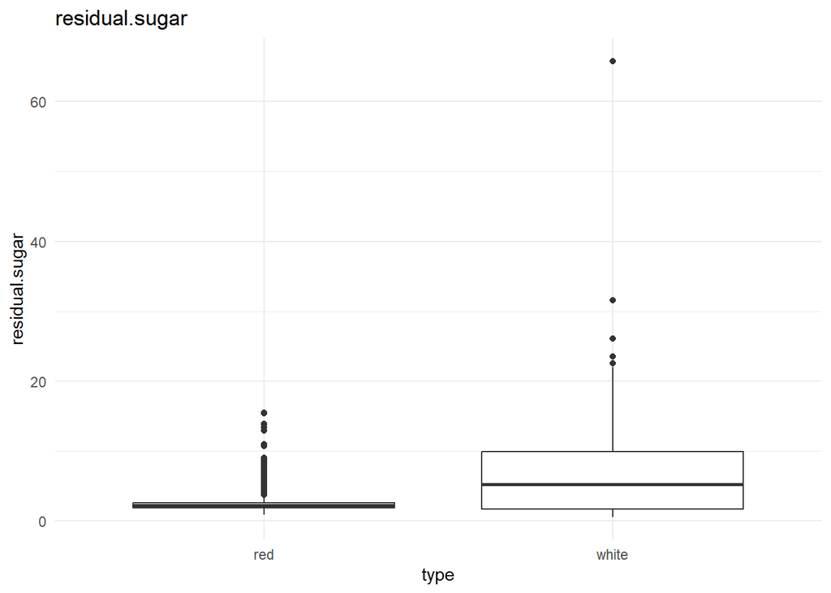

Key Chemical Properties by Wine Type

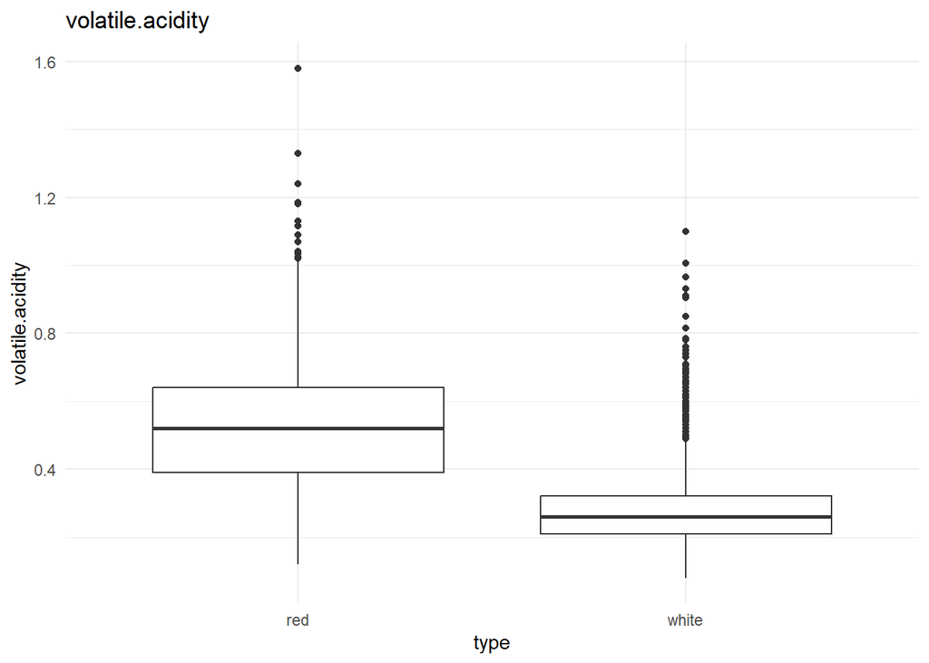

Key Chemical Properties by Wine Type

```r
features <- c("alcohol", "pH", "residual.sugar", "volatile.acidity")
plot_list <- lapply(features, function(feat) {
  ggplot(data, aes(x = type, y = .data[[feat]])) +
    geom_boxplot() +
    labs(title = feat, y = feat) +
    theme_minimal()
})

# Print all plots
a <- plot_list[[1]]
for(p in plot_list) print(p)
```

**Interpretation of `chemical-boxplots`:** This visualization or summary highlights a key trend or distribution in the data. For example, examine how the variable in question relates to wine quality or type. Look for outliers, skewness, or differences that inform the business question. > The first box-plot compares alcohol levels for red and white wine. The white wine has a higher median than the red wine and most of the white wine’s data points are clustered towards the top while the red wine’s data points are clustered more towards the bottom. This means that on average, white wine contains more alcohol than red wine.

The third box-plot compares the levels of residual sugar. While looking at the box-plot, one could infer that since white wine data points cluster towards the top, it is safe to say that white wine tends to be sweeter than red wine since the red wine data points are clustered more twoards the bottom.

Finally, the last box-plot compares the wines’ data based off of volatile acidity. While studying the box-plot, it is shown that the red wine quartile range has a higher value than the white wine’s range, meaning that red wine tends to have a higher volatile acidity. One question to ask would be “What is the difference between ph level testing and volatile acidity?” The main difference is that the two measure different ideas of acid. Ph levels are often the measure how strong the acid feeling is while you consume something acidic. On the contrary volatile acidity “is a measure of the low molecular weight (or steam distillable) fatty acids in wine and is generally percieved as the odour of vinegar” (Australian Wine Research Institute, 2018, p. 2).

Lastly, these are important chemical differences to look into becasue most of the time it depends on what the consumer is preferring, whether it is a less acidic feeling while drinking, the amount of alcohol, the amount of sugar, or the amount of fatty acids in their wine.

### Correlation Heatmaps

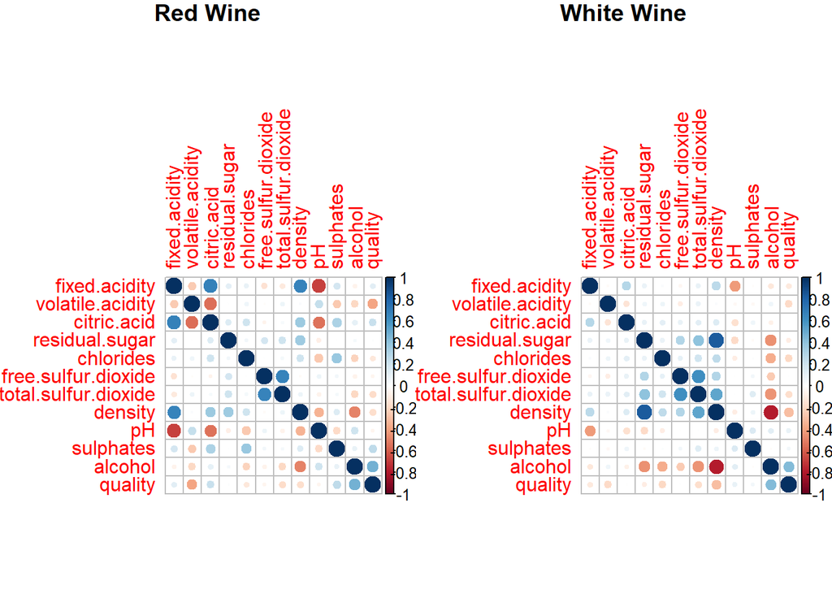

Correlation Matrices for Red and White Wines

```r
cor_red   <- cor(filter(data, type == "red")   %>% select(-type))
cor_white <- cor(filter(data, type == "white") %>% select(-type))

par(mfrow = c(1,2))
corrplot(cor_red,   main = "Red Wine",   mar = c(0,0,1,0))
corrplot(cor_white, main = "White Wine", mar = c(0,0,1,0))
```

```r
par(mfrow = c(1,1))
```

**Interpretation of `correlation-heatmaps`:** This visualization or summary highlights a key trend or distribution in the data. For example, examine how the variable in question relates to wine quality or type. Look for outliers, skewness, or differences that inform the business question. > Similarly to the box plots above, these correlational heatmaps only test the chemical compisitions in wine. However, the box-plots only compared the marginal distributions between the red and white wine. The correlational heatmaps test the relationship between quality and chemicals that are inside. The darer the circle, the strongher the correlation. The darker the blue, the more of a positve correlation while if it has a red shade, it is closer to a negative correlation. While looking at the some of the circles for red wine, it is clear that ph and alcohol do not have that strong of a coreelation with one another because the circle is light blue, meaning that its value is not close to one or negative one. One strong relationship that one could pull from the heatmap is that alcohol and quality have a strong correlational relationship. Compared to white wine, it has a slightly darker color menaing that the relationship between quality and alcohol is stronger in red.

## Statistical Testing

### T-Test for Mean Quality

```r
ttest <- t.test(quality ~ type, data = data)
tidy(ttest)
```

| estimate | estimate1 | estimate2 | statistic | p.value | parameter | conf.low | conf.high | method | alternative |
| --- | --- | --- | --- | --- | --- | --- | --- | --- | --- |
| -0.2418868 | 5.636023 | 5.877909 | -10.14936 | 8.168349e-24 | 2950.75 | -0.2886173 | -0.1951564 | Welch Two Sample t-test | two.sided |

> The purpose of this is to run a two-sample t-test comparing the means of white and red wine. Estimate one represents the mean quality red wine while Estimate 2 represents the mean quality of white wine. As shown, white wine has a higher mean quality proving that white wine is favored more by consumers.

### Alcohol vs Quality Correlation

```r
cor_red_alc   <- cor.test(filter(data, type == "red")$alcohol,
                            filter(data, type == "red")$quality)
cor_white_alc <- cor.test(filter(data, type == "white")$alcohol,
                            filter(data, type == "white")$quality)

list(
  red   = tidy(cor_red_alc),
  white = tidy(cor_white_alc)
)
```

```
## $red
## # A tibble: 1 × 8
##   estimate statistic  p.value parameter conf.low conf.high method    alternative
##      <dbl>     <dbl>    <dbl>     <int>    <dbl>     <dbl> <chr>     <chr>
## 1    0.476      21.6 2.83e-91      1597    0.437     0.513 Pearson'… two.sided
##
## $white
## # A tibble: 1 × 8
##   estimate statistic   p.value parameter conf.low conf.high method   alternative
##      <dbl>     <dbl>     <dbl>     <int>    <dbl>     <dbl> <chr>    <chr>
## 1    0.436      33.9 5.61e-226      4896    0.413     0.458 Pearson… two.sided
```

> For this table, we decided to run a pearson correlation between qualtiy and alcohol level. We already compared the two wines with these statistics in the heatmap above. Similarly, it is proven that both wines have a strong relationship when it comes quality and alcohol. Additionally, it is also proven that red wine has a stronger link between the two than white wine but only by a small marigin. Both of the p-vaulues being significant proves these tests are legit and the results we gathered during this study is reliable.